# 11 DIF analysis

Psychologisches Institut, Lehrstuhl für psychologische Methodenlehre, Evaluation und Statistik

Carolina Fellinghauer

carolina.fellinghauer@uzh.ch

25 11 2020

# Getting ready

Please include the following libraries:

```r
# install and load following R-packages library(iarm)
library(eRm)
library(iarm)
library(PP)  #used by the anova_DIF function
```

and load the Stress Related Growth data (SRG) :

```r
urlfile <- "https://raw.githubusercontent.com/CarolinaFellinghauer/UNIZH_HS2020_Rasch/master/Data/SRG_Data_Course_UNIZH.csv?token=AB5GB47UIUWV7F5NMGA33T27K5IQ2"

srg.data <- read.csv(url(urlfile))

dim(srg.data)
```

```
[1] 450  26
```

```r
colnames(srg.data)
```

```
 [1] "X"                      "ID"                     "Age"
 [4] "Gender"                 "Completeness"           "para.tetra_1"
 [7] "traumatic_nontraumatic" "PersStat"               "SRG1"
[10] "SRG2"                   "SRG3"                   "SRG4"
[13] "SRG5"                   "SRG6"                   "SRG7"
[16] "SRG8"                   "SRG9"                   "SRG10"
[19] "SRG11"                  "SRG12"                  "SRG13"
[22] "SRG14"                  "SRG15"                  "TP"
[25] "ID_Unik"                "wgt"
```

```r
srg.items <- c("SRG1", "SRG2", "SRG3", "SRG4", "SRG5", "SRG6", "SRG7", "SRG8", "SRG9",
    "SRG10", "SRG11", "SRG12", "SRG13", "SRG14", "SRG15")

# create age groups based < 30 < 45 < 60 < the break choice here is, admittedly,
# a bit random

srg.data[, "Age_grp"] <- cut(srg.data[, "Age"], breaks = c(0, 30, 45, 60, 85))

# exogenous variables to test DIF for
srg.pf <- c("Age", "Age_grp", "Gender", "Completeness", "para.tetra_1", "traumatic_nontraumatic")

# dataset with SRG items and the person factors
data.srg <- srg.data[, c(srg.items, srg.pf)]

# check response coding (frequencies including missing values) for each SRG-item
# apply(data.srg, 2, table, useNA='always')

# recode traumatic_nontraumatic = 3 to NA

data.srg[which(data.srg[, "traumatic_nontraumatic"] == 3), "traumatic_nontraumatic"] <- NA
```

# Differential Item Functioning

The items’ invariance to group effects is tested through a so called Differential Item Functioning (DIF) procedure. Given an ability level, the response to an item should be the same, irrespective of group membership (e.g. gender, age…).

DIF indicates the lack of invariance of an item difficulty to an exogenous variable (Boone, Staver, and Yale 2014). In general, it is understood that DIF occurs when sample subgroups respond differently to an individual item despite equal level of ability. For example, in a math examination, independently of their level in maths, participants who are not fluent in the language of the examination may be penalized. These systematic differences in the responses can be problematic as they indicate that the questionnaire is not fair across the complete sample and comparisons across subgroups can be problematic. For example, in an educational test with DIF, items may disadvantage one subgroup against the other. In principle, items with DIF could make a scale unsuitable for measurement and comparisons across a population. But, it is not so simple.

To understand DIF, the person map below may be helpful. This figure is invented and should represent the outcome of a Rasch analysis of a 5 item scale, with 3 response options. The sample consists of 10’000 persons, which can be divided into 2 subgroups A and B (for example: male versus female, below versus above 50 years, working not working).

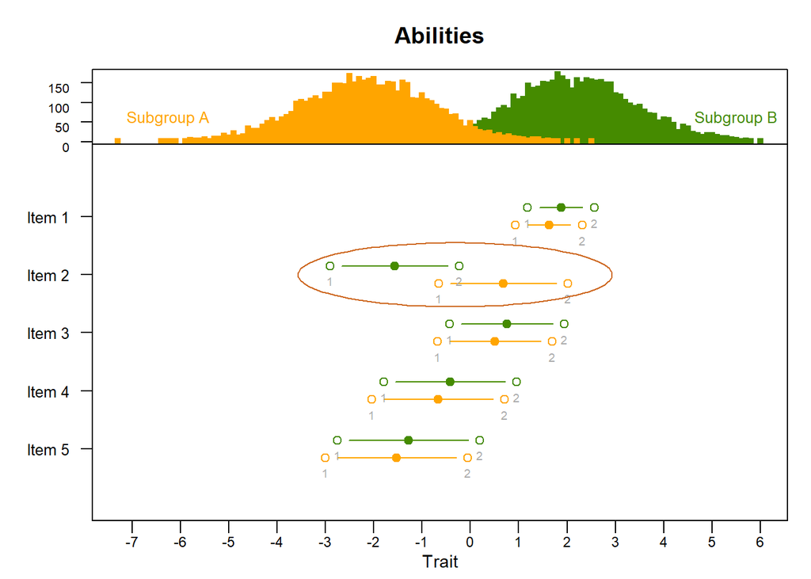

They are two observations with regard to the person item map above. First, the Subgroup B has significantly higher ability than Subgroup A. The differences in ability between the Subgroup A and the Subgroup B may not be measurement bias. In that sense, observing a difference in the mean location of sample subgroups is not evidence of problems with the construct validity.  
Second, except for *Item 2* all items have similar item difficulty for Subgroup A and Subgroup B. *Item 2* as can be seen is perceived as more difficult by the Subgroup A, as shown by the higher item difficulty. *Item 2* exhibits DIF, for a given level of ability, the response difficulty is very different between Subgroup A and Subgroup B. It is not likely that the shift in ability is caused by the difference in difficulty see in *Item 2*.

Items are checked for DIF for exogenous variables, i.e. person or sample characteristics, typically for ‘age group’, ‘gender’, but also for ‘educational level’, ‘health condition’, ‘country’, ‘language’, ‘survey year’, etc. The decision on which sample characteristics to test for item DIF is left to the researcher. However, a sufficient number of cases in the subgroups, with responses to the items response options, are necessary to perform a reliable DIF analysis.

If an item shows DIF, the item can be either removed, split or the model has to be extended to take into account the DIF (ex. multi-group analysis). There are two types of DIF: uniform and non-uniform DIF. Uniform DIF means that the difference between some subgroups is consistent over the range of ability levels, non-uniform DIF means inconsistent differences.

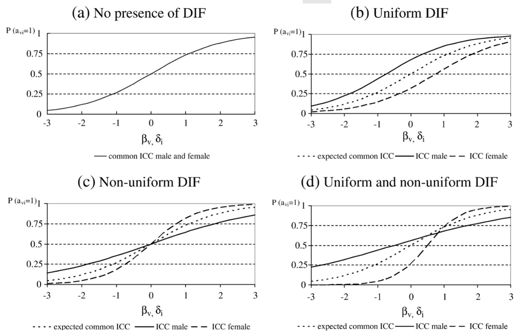

Example : DIF-Types

The example shows ICC curves, with the response probability for a dichotomous questionnaire item given an ability level. The expected response probability is shown for the sample with the dotted curve, a curve for female participants (dashed), and a curve for male participants (continuous) (Salzberger, Newton, and Ewing 2014). In absence of DIF, the subgroup lines are close to each other, following the expected probability curve. In uniform DIF, the curves are parallel with one subgroup systematically above the other. With non-uniform DIF the subgroup lines cross, with higher abilities of a subgroup in the lower score levels and higher abilities for the other subgroup in the higher score levels.

There are many different ways to test for DIF, what follows presents only one approach which is applicable for dichotomous as well as polytomous item types, the two-way ANOVA of the residuals.

# Diagnostics

## Numeric Output Analysis

### Two-way ANOVA

What follows shows one approach to detect DIF, i.e. an analysis of the residuals with ANOVA. Unfortunately, the package `eRm` does not contain functions for DIF analysis with polytomous data, only for dichotomous items (`LRtest` & `plotDIF`).

ANOVA or analysis of variance is a statistical approach that is interested in the “variation” among and between groups to analyze the differences among subgroup means in a sample.

A two-way ANOVA tests the effect of two grouping variables on the outcome. The outcome in this setting would be the residuals of a Rasch analysis. Such a function is found here for :

```r
urldif <- "https://raw.githubusercontent.com/CarolinaFellinghauer/UNIZH_HS2020_Rasch/master/RFunctions/anova_DIF.r"

source(url(urldif))
```

The grouping variables would be a person factor and the class interval (`ci`). The `ci` refers to the total score. In fact, participants are grouped according to their total score, called `ci` groups - from low to high `ci`. The `ci` are built equally sized, i.e. with more or less same number of partipants per `ci`. The number of `ci` depends on the sample size, with approximately 30-50 cases per `ci`.

In the SRG-dataset, the exogenous or DIF-variables chosen to show how to run a DIF analysis are `Gender` and `para_tetra_1`, the level of the spinal cord injury.

With a sample size of N = 450, to have around 50 people per score class interval, can be achieved with about 9 of `ci`, with the option `nci=`.

```r
DIF.srg.gender = anova_DIF(data.srg[,srg.items],
                    data.srg$Gender,
                    model = "PCM",
                    nci = 9,  #number of score class interval
                    p.adj="BH") #correction for multiple testing
DIF.srg.gender
```

```
$`data.srg$Gender`
$`data.srg$Gender`$SRG1
                       Df Sum Sq Mean Sq F value p.adj.BH
ci                      8   18.0  2.2547   2.462   0.5839
data.srg$Gender         1    1.3  1.2719   1.389   1.0000
ci:data.srg$Gender      8   11.3  1.4163   1.546   1.0000
Residuals             412  377.4  0.9159
8 observations deleted due to missingness

$`data.srg$Gender`$SRG2
                       Df Sum Sq Mean Sq F value p.adj.BH
ci                      8   20.4   2.550   2.553   0.3418
data.srg$Gender         1    5.9   5.938   5.944   0.3418
ci:data.srg$Gender      8    9.1   1.143   1.144   1.0000
Residuals             412  411.6   0.999
8 observations deleted due to missingness

$`data.srg$Gender`$SRG3
                       Df Sum Sq Mean Sq F value p.adj.BH
ci                      8   32.4   4.050   4.015   0.0059
data.srg$Gender         1    0.3   0.270   0.267   1.0000
ci:data.srg$Gender      8   27.4   3.426   3.395   0.0194
Residuals             415  418.7   1.009
5 observations deleted due to missingness

$`data.srg$Gender`$SRG4
                       Df Sum Sq Mean Sq F value p.adj.BH
ci                      8    8.1   1.017   0.994        1
data.srg$Gender         1    2.8   2.783   2.719        1
ci:data.srg$Gender      8   12.8   1.600   1.563        1
Residuals             414  423.8   1.024
6 observations deleted due to missingness

$`data.srg$Gender`$SRG5
                       Df Sum Sq Mean Sq F value p.adj.BH
ci                      8   20.9  2.6119   2.958   0.1411
data.srg$Gender         1    0.1  0.0909   0.103   1.0000
ci:data.srg$Gender      8    8.2  1.0310   1.168   1.0000
Residuals             416  367.3  0.8829
4 observations deleted due to missingness
```

[output cut: 65 more lines]

```
$`data.srg$Gender`$SRG14
                       Df Sum Sq Mean Sq F value p.adj.BH
ci                      8  13.94  1.7423   2.334   0.4152
data.srg$Gender         1   0.50  0.5004   0.670   1.0000
ci:data.srg$Gender      8  18.60  2.3250   3.114   0.0894
Residuals             416 310.56  0.7465
4 observations deleted due to missingness

$`data.srg$Gender`$SRG15
                       Df Sum Sq Mean Sq F value p.adj.BH
ci                      8   76.3   9.541   6.564   0.0000
data.srg$Gender         1    2.1   2.084   1.434   1.0000
ci:data.srg$Gender      8   35.3   4.409   3.033   0.0567
Residuals             416  604.7   1.454
4 observations deleted due to missingness
```

With the Benjamini-Hochberg correction for the false discovery rate (`p.adj="BH"`: recommended approach), the lowest *p*-value for the Gender effect is found for *SRG2 I feel freer to make my own decisions* (*F*-test = 5.944; *p*-value = 0.3418). The analysis supports no evidence for uniform DIF for Gender of the *SRG* scale, as no *F*-value reaches significance (i.e. no *p*-value < 0.05). Non-uniform DIF is observed for several SRG items *SRG3 I learned that I have something of value to teach others about life* (*F*-test = 3.395; *p*-value = 0.0194), *SRG10 I learned to be open to new information and ideas* (*F*-test = 3.467; *p*-value = 0.0313), and *SRG11 I learned to communicate more honestly with others* (*F*-test = 4.017; *p*-value = 0.0059). Non-uniform DIF indicates that the systematic difference in the difficulty of the item is associated to the participant’s SRG score and the gender.

Now, the injury level, paraplegia versus tetraplegia is tested for DIF. Let’s assume a difference in the stress related growth between persons with paraplegia or tetraplegia can bias the scale. Paraplegia often results in loss of sensation or paralysis of the lower body part. Persons with tetraplegia have the upper body part which is paralized or lacks of sensations.

```r
DIF.srg.level <- anova_DIF(data.srg[, srg.items], data.srg$para.tetra_1, model = "PCM",
    nci = 9, p.adj = "BH")  #correction for multiple testing
DIF.srg.level
```

```
$`data.srg$para.tetra_1`
$`data.srg$para.tetra_1`$SRG1
                          Df Sum Sq Mean Sq F value p.adj.BH
ci                         8  21.98  2.7479   3.078   0.0517
data.srg$para.tetra_1      1   1.86  1.8619   2.086   1.0000
ci:data.srg$para.tetra_1   8  24.08  3.0101   3.372   0.0437
Residuals                345 307.97  0.8927
75 observations deleted due to missingness

$`data.srg$para.tetra_1`$SRG2
                          Df Sum Sq Mean Sq F value p.adj.BH
ci                         8  22.38   2.798   3.087   0.0504
data.srg$para.tetra_1      1   0.39   0.393   0.433   1.0000
ci:data.srg$para.tetra_1   8  26.99   3.374   3.723   0.0154
Residuals                345 312.67   0.906
75 observations deleted due to missingness

$`data.srg$para.tetra_1`$SRG3
                          Df Sum Sq Mean Sq F value p.adj.BH
ci                         8   24.2   3.028   2.868   0.0948
data.srg$para.tetra_1      1    9.6   9.620   9.111   0.0948
ci:data.srg$para.tetra_1   8   15.8   1.970   1.866   0.9657
Residuals                348  367.4   1.056
72 observations deleted due to missingness

$`data.srg$para.tetra_1`$SRG4
                          Df Sum Sq Mean Sq F value p.adj.BH
ci                         8    8.8  1.1061   1.135        1
data.srg$para.tetra_1      1    2.3  2.3488   2.410        1
ci:data.srg$para.tetra_1   8    7.3  0.9100   0.934        1
Residuals                347  338.2  0.9746
73 observations deleted due to missingness

$`data.srg$para.tetra_1`$SRG5
                          Df Sum Sq Mean Sq F value p.adj.BH
ci                         8  19.89  2.4862   2.852   0.0992
data.srg$para.tetra_1      1   0.64  0.6421   0.737   1.0000
ci:data.srg$para.tetra_1   8  20.86  2.6075   2.991   0.0992
Residuals                349 304.25  0.8718
71 observations deleted due to missingness
```

[output cut: 65 more lines]

```
$`data.srg$para.tetra_1`$SRG14
                          Df Sum Sq Mean Sq F value p.adj.BH
ci                         8  12.69  1.5862   2.049        1
data.srg$para.tetra_1      1   1.23  1.2286   1.587        1
ci:data.srg$para.tetra_1   8   7.97  0.9961   1.287        1
Residuals                349 270.19  0.7742
71 observations deleted due to missingness

$`data.srg$para.tetra_1`$SRG15
                          Df Sum Sq Mean Sq F value p.adj.BH
ci                         8   74.9   9.360   6.775   0.0000
data.srg$para.tetra_1      1    0.2   0.171   0.124   1.0000
ci:data.srg$para.tetra_1   8   45.4   5.678   4.110   0.0024
Residuals                349  482.1   1.381
71 observations deleted due to missingness
```

The analysis with ANOVA indicates strong uniform DIF for the injury level for the item *SRG10 I learned to be open to new information and ideas* (*F*-value = 15.431; *p*-value = 0.0046). Non-uniform DIF is also observed, for *SRG1 I learned to be nicer to others*, *SRG2 I feel freer to make my own decisions*, *SRG9 I learned to listen more carefully when others talk to me*, *SRG13 I learned that it’s okay to ask others for help*, and *SRG15 I learned that there are more people who care about me than I thought*.

## Visual Analysis

The following plots, which show the item difficulty estimates across separate calibrations of the SRG data for subgroups of gender and lesion type.

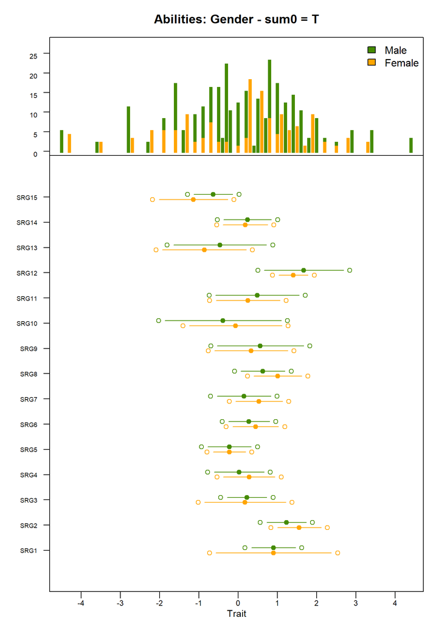

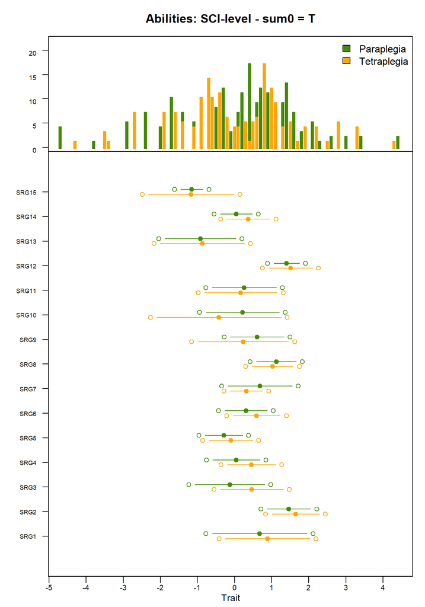

### ICC plot

The uniform DIF found in the numeric outputs is usually also visible on ICC plots with separate lines for levels of the person factor tested for. Such a function, is found in the package `iarm`. With polytomous data, instead of the response probability, the expected item score is drawn on the y-axis.

When the item is free of DIF and fitting the Rasch Model, the lines for the subgroup should fall as close as possible to the expected common score line. For example *SRG12* is free of Gender, and it is also a well fitting item.

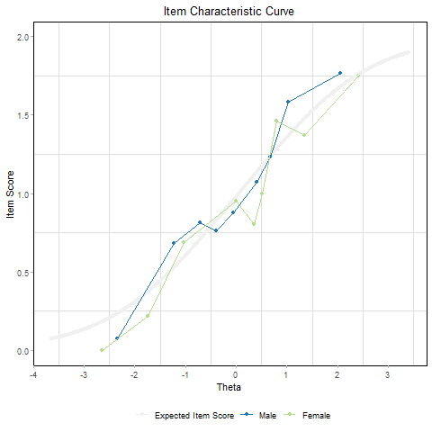

In comparison, the curves of the *Item 10* when tested for DIF for the injury level (paraplegia versus tetraplegia), which was significant (*p*-value = 0.0046). The lines are away from the expected curve.

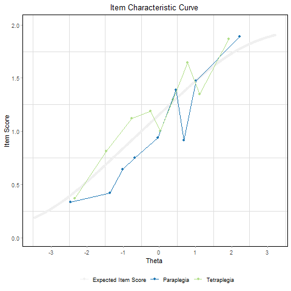

# Adjustment

In presence of uniform DIF, instead of deleting the item with DIF, the item can be split. Item split allows an item with DIF to have different difficulty estimates across subgroups. Splitting, however, will allow the difficulty of the items to differ across subgroups. As a consequence, not one psychometrically sound interval-scaled metric is developed but as many adjusted, subgroup specific metrics as subgroups that conducted to DIF.

Typically, item splitting is done stepwise, starting with the item showing the highest DIF on an exogeneous variable.

It is important to note that many methods for DIF analysis use the constraint that the mean of the item parameters is zero in each group for anchoring (in `eRm` even when the other constraint `sum0 = FALSE` is used for fitting the model). This constraint implicitly makes the assumption that DIF is balanced (some items prefer one group, some the other, and on average the DIF cancels out). However, this approach may cause so-called artificial DIF (Andrich and Hagquist 2014), i.e. smaller DIF in some items as a reaction to the large DIF in another or other items. To avoid this, so called anchor items can be selected by means of statistical procedures, but most methods for anchor item selection have been suggested only for binary Rasch models so far.

```r
# example of item split using the item 10 which showed very strong DIF for injury
# level (paraplegia and tetraplegia).

# here two new variables are created one for paraplegia and one for tetraplegia
# for each variable the options for the other injury group are set to missing.

srg.data[, "SRG10_P"] <- srg.data[, "SRG10"]
srg.data[which(srg.data[, "para.tetra_1"] == 1), "SRG10_P"] <- NA

srg.data[, "SRG10_T"] <- srg.data[, "SRG10"]
srg.data[which(srg.data[, "para.tetra_1"] == 0), "SRG10_T"] <- NA


# now instead one SRG10 item, there are two, one for each level of the injury
# etiology variable.

# the item SRG10 has to be removed or the list of SRG items has to be redefined.

srg.items <- c("SRG1", "SRG2", "SRG3", "SRG4", "SRG5", "SRG6", "SRG7", "SRG8", "SRG9",
    "SRG10_P", "SRG10_T", "SRG11", "SRG12", "SRG13", "SRG14", "SRG15")

head(srg.data[, srg.items])
```

```
  SRG1 SRG2 SRG3 SRG4 SRG5 SRG6 SRG7 SRG8 SRG9 SRG10_P SRG10_T SRG11 SRG12
1   NA   NA    2    1    0    1    1    1    0       0      NA     2     2
2    0    0    1    1    0    1    0    0    0       1      NA     1     0
3    1    0    1    1    1    1    2    0    2      NA       1     2     1
4    0    1    0    0    0    0    0    0    0       0      NA     0     0
5    2    2    2    2    2    2    2    1    2      NA       2     1     2
6    1    1    2    1    1    1    2    0    1      NA       2     1     2
  SRG13 SRG14 SRG15
1     2     1     2
2     0     0     0
3     2     2     1
4     1     0     0
5     2     1     2
6     1     2     0
```

The Rasch analysis is re-run with the item *SRG10 I learned to be open to new information and ideas* split for injury level. Here, the person item map to show the distribution of the item difficulty estimates.

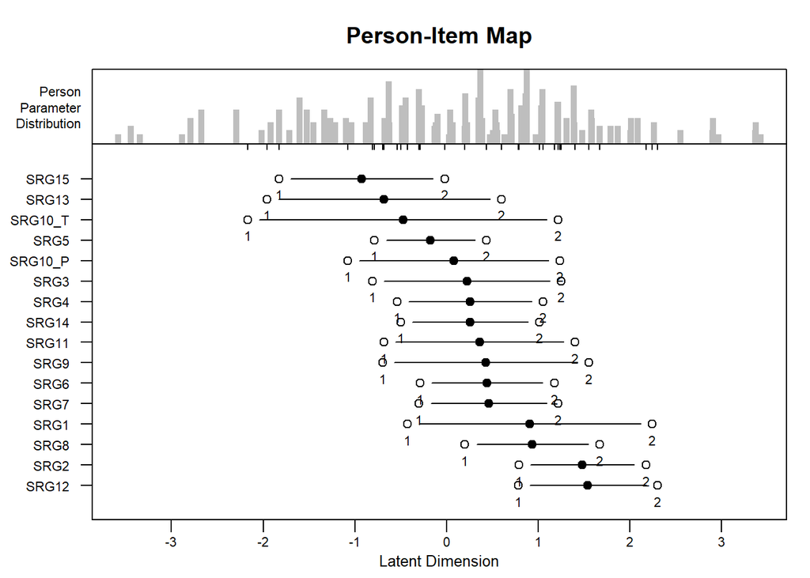

```r
plotPImap(PCM(srg.data[, srg.items]), sorted = TRUE)
```

At this stage, the Rasch analysis, has to be started from the beginning. That means, the item fit, the local item dependencies etc… are checked again… (and again)… until each assumption of the Rasch model meets the requirements.

# Exercise

Run the same DIF analysis for Age group (< 30 < 45 < 60), Completeness, and Injury etiology (Traumatic versus non-Traumatic). Decide if you would want to split items.

# References

Andrich, David, and Curt Hagquist. 2014. “Real and Artificial Differential Item Functioning in Polytomous Items.” *Educational and Psychological Measurement*, May. https://doi.org/10.1177/0013164414534258.

Boone, William J., John R. Staver, and Melissa S. Yale. 2014. *Rasch Analysis in the Human Sciences*.

Salzberger, Thomas, Fiona J. Newton, and Michael T. Ewing. 2014. “Detecting Gender Item Bias and Differential Manifest Response Behavior: A Rasch-Based Solution.” *Journal of Business Research* 67 (4): 598–607. https://doi.org/https://doi.org/10.1016/j.jbusres.2013.02.045.